# data612 ass 2

```r
movies <- read.csv("https://raw.githubusercontent.com/miasiracusa/Data607/master/Data612/Data%20612%20ass2/movies.csv")

ratings <- read.csv("https://raw.githubusercontent.com/miasiracusa/Data607/master/Data612/Data%20612%20ass2/ratings.csv")

#merge data frames by movieId

m <- merge(movies, ratings, by="movieId")
n <- data.matrix(m, rownames.force = NA)
data(MovieLense)
MovieLense
```

```
## 943 x 1664 rating matrix of class 'realRatingMatrix' with 99392 ratings.
```

[figure not shown]

The data appears to be skewed to the left. It also appears that people prefer to rate movies with whole numbers.

Next, I will only examine the most rated movies, so our data is more accurate.

```r
#pick the most relevant data points (in this case the most rated movies)
movies <- MovieLense[rowCounts(MovieLense) > 50, colCounts(MovieLense) > 100]
```

Next, I will create a train dataset and a test dataset

```r
train <- sample(x = c(TRUE, FALSE), size = nrow(movies),
                      replace = TRUE, prob = c(0.8, 0.2))

movieTrain <- movies[train, ]
movieTest <- movies[!train, ]
```

Next, I will use the cosine method to test for similarity among the movies.

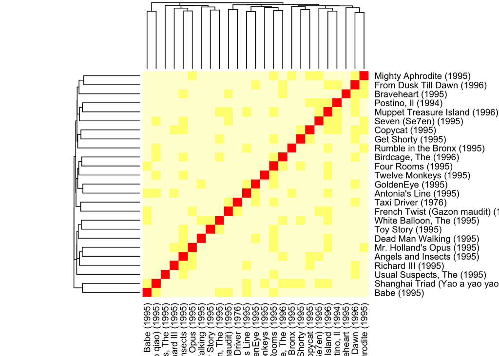

```r
similaritems <- similarity(MovieLense[, 1:25], method = "cosine", which = "items")
heatmap(as.matrix(similaritems))
```

The red indicates that there is a high similarity. This makes sense to appear along the diagonal, since the movies are being compared to themselves. The darker yellow indicates slgihtly more similar items. Now we will create an item to item model using the IBCF method.We will start with the training set.

```r
trainI2I <- Recommender(movieTrain, method = "IBCF", param=list(normalize = "Z-score", method="Jaccard"))
```

```r
predicted <- predict(object = trainI2I, newdata = movieTest, n = 10)
rec <- sapply(predicted@items, function(x) {colnames(movies)[x]})
rec %>% kable() %>% kable_styling(full_width = T)
```

| x |
| --- |
| GoldenEye (1995) |
| Get Shorty (1995) |
| Dead Man Walking (1995) |
| Mighty Aphrodite (1995) |
| Postino, Il (1994) |
| Taxi Driver (1976) |
| Rumble in the Bronx (1995) |
| Batman Forever (1995) |
| Net, The (1995) |
| Clerks (1994) |

| x |
| --- |
| GoldenEye (1995) |
| Get Shorty (1995) |
| Twelve Monkeys (1995) |
| Babe (1995) |
| Dead Man Walking (1995) |
| Seven (Se7en) (1995) |
| Usual Suspects, The (1995) |
| Mighty Aphrodite (1995) |
| Postino, Il (1994) |
| Mr. Holland’s Opus (1995) |

| x |
| --- |
| Devil’s Own, The (1997) |
| Dragonheart (1996) |
| First Wives Club, The (1996) |
| Executive Decision (1996) |
| Grumpier Old Men (1995) |
| Braveheart (1995) |
| Mystery Science Theater 3000: The Movie (1996) |
| Alien (1979) |
| Sling Blade (1996) |
| Heat (1995) |

| x |
| --- |
| Scream (1996) |
| GoldenEye (1995) |
| Get Shorty (1995) |
| Postino, Il (1994) |
| Mr. Holland’s Opus (1995) |
| Taxi Driver (1976) |
| Rumble in the Bronx (1995) |
| Apollo 13 (1995) |
| Batman Forever (1995) |
| Crimson Tide (1995) |

| x |
| --- |
| GoldenEye (1995) |
| Get Shorty (1995) |
| Twelve Monkeys (1995) |
| Dead Man Walking (1995) |
| Seven (Se7en) (1995) |
| Mighty Aphrodite (1995) |
| Postino, Il (1994) |
| Taxi Driver (1976) |
| Birdcage, The (1996) |
| Batman Forever (1995) |

| x |
| --- |
| Get Shorty (1995) |
| Seven (Se7en) (1995) |
| Postino, Il (1994) |
| Rumble in the Bronx (1995) |
| Batman Forever (1995) |
| Crimson Tide (1995) |
| Clerks (1994) |
| Ed Wood (1994) |
| Natural Born Killers (1994) |
| Professional, The (1994) |

| x |
| --- |
| Toy Story (1995) |
| GoldenEye (1995) |
| Get Shorty (1995) |
| Babe (1995) |
| Dead Man Walking (1995) |
| Seven (Se7en) (1995) |
| Postino, Il (1994) |
| Mr. Holland’s Opus (1995) |
| Braveheart (1995) |
| Birdcage, The (1996) |

| x |
| --- |
| Leaving Las Vegas (1995) |
| Twelve Monkeys (1995) |
| Scream (1996) |
| Down Periscope (1996) |
| Craft, The (1996) |
| Truth About Cats & Dogs, The (1996) |
| Frighteners, The (1996) |
| Long Kiss Goodnight, The (1996) |
| Willy Wonka and the Chocolate Factory (1971) |
| 101 Dalmatians (1996) |

| x |
| --- |
| GoldenEye (1995) |
| Get Shorty (1995) |
| Babe (1995) |
| Dead Man Walking (1995) |
| Seven (Se7en) (1995) |
| Usual Suspects, The (1995) |
| Braveheart (1995) |
| Taxi Driver (1976) |
| Rumble in the Bronx (1995) |
| Apollo 13 (1995) |

| x |
| --- |
| Scream (1996) |
| Twelve Monkeys (1995) |
| Mighty Aphrodite (1995) |
| Welcome to the Dollhouse (1995) |
| Cold Comfort Farm (1995) |
| Lone Star (1996) |
| Chasing Amy (1997) |
| Men in Black (1997) |
| Crash (1996) |
| Game, The (1997) |

| x |
| --- |
| Scream (1996) |
| Babe (1995) |
| Usual Suspects, The (1995) |
| Aladdin (1992) |
| Mystery Science Theater 3000: The Movie (1996) |
| Sling Blade (1996) |
| Heat (1995) |
| English Patient, The (1996) |
| Face/Off (1997) |
| Jackie Brown (1997) |

| x |
| --- |

| x |
| --- |
| Babe (1995) |
| Usual Suspects, The (1995) |
| Braveheart (1995) |
| Aladdin (1992) |
| Mystery Science Theater 3000: The Movie (1996) |
| Truth About Cats & Dogs, The (1996) |
| Independence Day (ID4) (1996) |
| Frighteners, The (1996) |
| Long Kiss Goodnight, The (1996) |
| Willy Wonka and the Chocolate Factory (1971) |

| x |
| --- |
| Truth About Cats & Dogs, The (1996) |
| Independence Day (ID4) (1996) |
| Frighteners, The (1996) |
| Long Kiss Goodnight, The (1996) |
| Willy Wonka and the Chocolate Factory (1971) |
| 101 Dalmatians (1996) |
| Beavis and Butt-head Do America (1996) |
| Jungle2Jungle (1997) |
| Leaving Las Vegas (1995) |
| Scream (1996) |

| x |
| --- |
| Toy Story (1995) |
| GoldenEye (1995) |
| Get Shorty (1995) |
| Twelve Monkeys (1995) |
| Babe (1995) |
| Dead Man Walking (1995) |
| Usual Suspects, The (1995) |
| Mighty Aphrodite (1995) |
| Postino, Il (1994) |
| Mr. Holland’s Opus (1995) |

| x |
| --- |
| Mr. Holland’s Opus (1995) |
| Twister (1996) |
| Big Night (1996) |
| Jerry Maguire (1996) |
| Devil’s Own, The (1997) |
| Absolute Power (1997) |
| Everyone Says I Love You (1996) |
| Mission: Impossible (1996) |
| Dragonheart (1996) |
| First Wives Club, The (1996) |

| x |
| --- |

| x |
| --- |
| Birdcage, The (1996) |
| Devil’s Own, The (1997) |
| Absolute Power (1997) |
| Liar Liar (1997) |
| Nutty Professor, The (1996) |
| Dragonheart (1996) |
| First Wives Club, The (1996) |
| Hunchback of Notre Dame, The (1996) |
| Executive Decision (1996) |
| Ransom (1996) |

| x |
| --- |
| Truth About Cats & Dogs, The (1996) |
| Frighteners, The (1996) |
| Willy Wonka and the Chocolate Factory (1971) |
| Beavis and Butt-head Do America (1996) |
| Leaving Las Vegas (1995) |
| Titanic (1997) |
| Dante’s Peak (1997) |
| James and the Giant Peach (1996) |
| Down Periscope (1996) |
| Craft, The (1996) |

| x |
| --- |
| Scream (1996) |
| Titanic (1997) |
| English Patient, The (1996) |
| Babe (1995) |
| Usual Suspects, The (1995) |
| Braveheart (1995) |
| Mystery Science Theater 3000: The Movie (1996) |
| Truth About Cats & Dogs, The (1996) |
| Frighteners, The (1996) |
| Long Kiss Goodnight, The (1996) |

| x |
| --- |
| Frighteners, The (1996) |
| Long Kiss Goodnight, The (1996) |
| Willy Wonka and the Chocolate Factory (1971) |
| Beavis and Butt-head Do America (1996) |
| James and the Giant Peach (1996) |
| Craft, The (1996) |
| Star Wars (1977) |
| Big Night (1996) |
| Star Trek: First Contact (1996) |
| Sense and Sensibility (1995) |

| x |
| --- |
| Scream (1996) |
| Truth About Cats & Dogs, The (1996) |
| Independence Day (ID4) (1996) |
| Frighteners, The (1996) |
| Willy Wonka and the Chocolate Factory (1971) |
| 101 Dalmatians (1996) |
| Beavis and Butt-head Do America (1996) |
| James and the Giant Peach (1996) |
| Broken Arrow (1996) |
| Down Periscope (1996) |

| x |
| --- |
| Babe (1995) |
| Braveheart (1995) |
| Mystery Science Theater 3000: The Movie (1996) |
| Indiana Jones and the Last Crusade (1989) |
| Heat (1995) |
| English Patient, The (1996) |
| Face/Off (1997) |
| Schindler’s List (1993) |
| Jackie Brown (1997) |
| Butch Cassidy and the Sundance Kid (1969) |

| x |
| --- |
| Scream (1996) |
| Truth About Cats & Dogs, The (1996) |
| Frighteners, The (1996) |
| Long Kiss Goodnight, The (1996) |
| Leaving Las Vegas (1995) |
| James and the Giant Peach (1996) |
| Broken Arrow (1996) |
| Down Periscope (1996) |
| Craft, The (1996) |
| GoldenEye (1995) |

| x |
| --- |
| Titanic (1997) |
| Leaving Las Vegas (1995) |
| Down Periscope (1996) |
| Craft, The (1996) |
| Truth About Cats & Dogs, The (1996) |
| Independence Day (ID4) (1996) |
| Long Kiss Goodnight, The (1996) |
| Willy Wonka and the Chocolate Factory (1971) |
| 101 Dalmatians (1996) |
| Jungle2Jungle (1997) |

| x |
| --- |
| Scream (1996) |
| Titanic (1997) |
| Toy Story (1995) |
| GoldenEye (1995) |
| Get Shorty (1995) |
| Twelve Monkeys (1995) |
| Babe (1995) |
| Dead Man Walking (1995) |
| Seven (Se7en) (1995) |
| Postino, Il (1994) |

| x |
| --- |
| Mighty Aphrodite (1995) |
| Postino, Il (1994) |
| Taxi Driver (1976) |
| Net, The (1995) |
| Hoop Dreams (1994) |
| Professional, The (1994) |
| What’s Eating Gilbert Grape (1993) |
| Four Weddings and a Funeral (1994) |
| Mask, The (1994) |
| Much Ado About Nothing (1993) |

| x |
| --- |
| Truth About Cats & Dogs, The (1996) |
| 101 Dalmatians (1996) |
| Beavis and Butt-head Do America (1996) |
| Jungle2Jungle (1997) |
| Dante’s Peak (1997) |
| Down Periscope (1996) |
| Executive Decision (1996) |
| Father of the Bride Part II (1995) |
| Mighty Aphrodite (1995) |
| Welcome to the Dollhouse (1995) |

| x |
| --- |
| Frighteners, The (1996) |
| 101 Dalmatians (1996) |
| Beavis and Butt-head Do America (1996) |
| Jungle2Jungle (1997) |
| Dante’s Peak (1997) |
| James and the Giant Peach (1996) |
| Down Periscope (1996) |
| Craft, The (1996) |
| Titanic (1997) |
| GoldenEye (1995) |

| x |
| --- |
| Toy Story (1995) |
| Star Trek: First Contact (1996) |
| Emma (1996) |
| Everyone Says I Love You (1996) |
| Seven Years in Tibet (1997) |
| GoldenEye (1995) |
| Twelve Monkeys (1995) |
| Dead Man Walking (1995) |
| Seven (Se7en) (1995) |
| Mighty Aphrodite (1995) |

| x |
| --- |
| Mighty Aphrodite (1995) |
| Welcome to the Dollhouse (1995) |
| Cold Comfort Farm (1995) |
| Lone Star (1996) |
| Swingers (1996) |
| Chasing Amy (1997) |
| Contact (1997) |
| Full Monty, The (1997) |
| Secrets & Lies (1996) |
| In & Out (1997) |

| x |
| --- |
| Scream (1996) |

| x |
| --- |
| Scream (1996) |
| GoldenEye (1995) |
| Postino, Il (1994) |
| Rumble in the Bronx (1995) |
| Clerks (1994) |
| Ed Wood (1994) |
| Hoop Dreams (1994) |
| Natural Born Killers (1994) |
| While You Were Sleeping (1995) |
| Ace Ventura: Pet Detective (1994) |

| x |
| --- |
| Frighteners, The (1996) |
| Long Kiss Goodnight, The (1996) |
| Beavis and Butt-head Do America (1996) |
| Jungle2Jungle (1997) |
| Dante’s Peak (1997) |
| James and the Giant Peach (1996) |
| Broken Arrow (1996) |
| Down Periscope (1996) |
| Craft, The (1996) |
| Toy Story (1995) |

| x |
| --- |
| GoldenEye (1995) |
| Get Shorty (1995) |
| Twelve Monkeys (1995) |
| Babe (1995) |
| Dead Man Walking (1995) |
| Seven (Se7en) (1995) |
| Usual Suspects, The (1995) |
| Mighty Aphrodite (1995) |
| Postino, Il (1994) |
| Mr. Holland’s Opus (1995) |

| x |
| --- |
| Executive Decision (1996) |
| Grumpier Old Men (1995) |
| Frighteners, The (1996) |
| Long Kiss Goodnight, The (1996) |
| 101 Dalmatians (1996) |
| Beavis and Butt-head Do America (1996) |
| Jungle2Jungle (1997) |
| Dante’s Peak (1997) |
| Mr. Holland’s Opus (1995) |
| Liar Liar (1997) |

| x |
| --- |
| Toy Story (1995) |
| Dead Man Walking (1995) |
| Mighty Aphrodite (1995) |
| Postino, Il (1994) |
| Mr. Holland’s Opus (1995) |
| Taxi Driver (1976) |
| Rumble in the Bronx (1995) |
| Birdcage, The (1996) |
| Apollo 13 (1995) |
| Clerks (1994) |

| x |
| --- |
| Down Periscope (1996) |
| Craft, The (1996) |
| Toy Story (1995) |
| GoldenEye (1995) |
| Get Shorty (1995) |
| Seven (Se7en) (1995) |
| Mr. Holland’s Opus (1995) |
| Taxi Driver (1976) |
| Rumble in the Bronx (1995) |
| Apollo 13 (1995) |

| x |
| --- |
| Absolute Power (1997) |
| Dragonheart (1996) |
| Sleepers (1996) |
| Executive Decision (1996) |
| Long Kiss Goodnight, The (1996) |
| Beavis and Butt-head Do America (1996) |
| Jungle2Jungle (1997) |
| Taxi Driver (1976) |
| Rumble in the Bronx (1995) |
| Mask, The (1994) |

| x |
| --- |
| GoldenEye (1995) |
| Dead Man Walking (1995) |
| Seven (Se7en) (1995) |
| Postino, Il (1994) |
| Taxi Driver (1976) |
| Ed Wood (1994) |
| Hoop Dreams (1994) |
| Natural Born Killers (1994) |
| Outbreak (1995) |
| Professional, The (1994) |

| x |
| --- |
| Twelve Monkeys (1995) |
| Birdcage, The (1996) |
| Devil’s Own, The (1997) |
| Liar Liar (1997) |
| Nutty Professor, The (1996) |
| Dragonheart (1996) |
| First Wives Club, The (1996) |
| Hunchback of Notre Dame, The (1996) |
| Executive Decision (1996) |
| Father of the Bride Part II (1995) |

| x |
| --- |
| Truth About Cats & Dogs, The (1996) |
| Long Kiss Goodnight, The (1996) |
| 101 Dalmatians (1996) |
| Jungle2Jungle (1997) |
| Dante’s Peak (1997) |
| James and the Giant Peach (1996) |
| Broken Arrow (1996) |
| Executive Decision (1996) |
| Ransom (1996) |
| Down Periscope (1996) |

| x |
| --- |

| x |
| --- |
| Toy Story (1995) |
| GoldenEye (1995) |
| Get Shorty (1995) |
| Seven (Se7en) (1995) |
| Mighty Aphrodite (1995) |
| Postino, Il (1994) |
| Mr. Holland’s Opus (1995) |
| Taxi Driver (1976) |
| Rumble in the Bronx (1995) |
| Birdcage, The (1996) |

| x |
| --- |
| GoldenEye (1995) |
| Get Shorty (1995) |
| Babe (1995) |
| Dead Man Walking (1995) |
| Seven (Se7en) (1995) |
| Usual Suspects, The (1995) |
| Mighty Aphrodite (1995) |
| Postino, Il (1994) |
| Braveheart (1995) |
| Taxi Driver (1976) |

| x |
| --- |
| Titanic (1997) |
| Twelve Monkeys (1995) |
| Babe (1995) |
| Usual Suspects, The (1995) |
| Braveheart (1995) |
| Aladdin (1992) |
| Fargo (1996) |
| Mystery Science Theater 3000: The Movie (1996) |
| Return of the Jedi (1983) |
| Alien (1979) |

| x |
| --- |
| Truth About Cats & Dogs, The (1996) |
| Independence Day (ID4) (1996) |
| Frighteners, The (1996) |
| Long Kiss Goodnight, The (1996) |
| 101 Dalmatians (1996) |
| Beavis and Butt-head Do America (1996) |
| Jungle2Jungle (1997) |
| Dante’s Peak (1997) |
| James and the Giant Peach (1996) |
| Broken Arrow (1996) |

| x |
| --- |
| Truth About Cats & Dogs, The (1996) |
| Willy Wonka and the Chocolate Factory (1971) |
| 101 Dalmatians (1996) |
| Beavis and Butt-head Do America (1996) |
| Jungle2Jungle (1997) |
| James and the Giant Peach (1996) |
| Down Periscope (1996) |
| Craft, The (1996) |
| Mighty Aphrodite (1995) |
| Taxi Driver (1976) |

| x |
| --- |
| Babe (1995) |
| Usual Suspects, The (1995) |
| Mystery Science Theater 3000: The Movie (1996) |
| Sling Blade (1996) |
| English Patient, The (1996) |
| Face/Off (1997) |
| Schindler’s List (1993) |
| Butch Cassidy and the Sundance Kid (1969) |
| Trainspotting (1996) |
| Vertigo (1958) |

| x |
| --- |
| Down Periscope (1996) |
| Craft, The (1996) |
| Frighteners, The (1996) |
| Long Kiss Goodnight, The (1996) |
| 101 Dalmatians (1996) |
| Beavis and Butt-head Do America (1996) |
| Jungle2Jungle (1997) |
| James and the Giant Peach (1996) |
| Broken Arrow (1996) |
| GoldenEye (1995) |

| x |
| --- |
| GoldenEye (1995) |
| Get Shorty (1995) |
| Babe (1995) |
| Dead Man Walking (1995) |
| Mighty Aphrodite (1995) |
| Postino, Il (1994) |
| Braveheart (1995) |
| Rumble in the Bronx (1995) |
| Birdcage, The (1996) |
| Batman Forever (1995) |

| x |
| --- |
| Toy Story (1995) |
| GoldenEye (1995) |
| Get Shorty (1995) |
| Twelve Monkeys (1995) |
| Dead Man Walking (1995) |
| Seven (Se7en) (1995) |
| Mighty Aphrodite (1995) |
| Postino, Il (1994) |
| Mr. Holland’s Opus (1995) |
| Taxi Driver (1976) |

| x |
| --- |
| Scream (1996) |
| Seven (Se7en) (1995) |
| Taxi Driver (1976) |
| Crimson Tide (1995) |
| Clerks (1994) |
| Ed Wood (1994) |
| Hoop Dreams (1994) |
| Outbreak (1995) |
| Professional, The (1994) |
| Quiz Show (1994) |

| x |
| --- |
| Truth About Cats & Dogs, The (1996) |
| Frighteners, The (1996) |
| Long Kiss Goodnight, The (1996) |
| Jungle2Jungle (1997) |
| Titanic (1997) |
| James and the Giant Peach (1996) |
| Down Periscope (1996) |
| English Patient, The (1996) |
| Seven Years in Tibet (1997) |
| Happy Gilmore (1996) |

| x |
| --- |
| Babe (1995) |
| Usual Suspects, The (1995) |
| Mystery Science Theater 3000: The Movie (1996) |
| Sling Blade (1996) |
| Heat (1995) |
| Face/Off (1997) |
| Schindler’s List (1993) |
| Jackie Brown (1997) |
| Trainspotting (1996) |
| Vertigo (1958) |

| x |
| --- |
| Toy Story (1995) |
| GoldenEye (1995) |
| Babe (1995) |
| Mighty Aphrodite (1995) |
| Mr. Holland’s Opus (1995) |
| Rumble in the Bronx (1995) |
| Birdcage, The (1996) |
| Batman Forever (1995) |
| Crimson Tide (1995) |
| Net, The (1995) |

| x |
| --- |
| Truth About Cats & Dogs, The (1996) |
| Independence Day (ID4) (1996) |
| Frighteners, The (1996) |
| Long Kiss Goodnight, The (1996) |
| Willy Wonka and the Chocolate Factory (1971) |
| 101 Dalmatians (1996) |
| Beavis and Butt-head Do America (1996) |
| Jungle2Jungle (1997) |
| Leaving Las Vegas (1995) |
| Scream (1996) |

| x |
| --- |
| Titanic (1997) |
| GoldenEye (1995) |
| Get Shorty (1995) |
| Twelve Monkeys (1995) |
| Dead Man Walking (1995) |
| Postino, Il (1994) |
| Rumble in the Bronx (1995) |
| Birdcage, The (1996) |
| Batman Forever (1995) |
| Crimson Tide (1995) |

| x |
| --- |
| Scream (1996) |
| Titanic (1997) |

| x |
| --- |
| GoldenEye (1995) |
| Get Shorty (1995) |
| Seven (Se7en) (1995) |
| Postino, Il (1994) |
| Rumble in the Bronx (1995) |
| Apollo 13 (1995) |
| Batman Forever (1995) |
| Crimson Tide (1995) |
| Net, The (1995) |
| Clerks (1994) |

| x |
| --- |
| Babe (1995) |
| Usual Suspects, The (1995) |
| Braveheart (1995) |
| Aladdin (1992) |
| Mystery Science Theater 3000: The Movie (1996) |
| Return of the Jedi (1983) |
| Alien (1979) |
| Indiana Jones and the Last Crusade (1989) |
| Sling Blade (1996) |
| Schindler’s List (1993) |

| x |
| --- |
| Scream (1996) |
| Titanic (1997) |
| Toy Story (1995) |
| GoldenEye (1995) |
| Get Shorty (1995) |
| Twelve Monkeys (1995) |
| Babe (1995) |
| Dead Man Walking (1995) |
| Seven (Se7en) (1995) |
| Usual Suspects, The (1995) |

| x |
| --- |
| GoldenEye (1995) |
| Batman Forever (1995) |
| Crimson Tide (1995) |
| Net, The (1995) |
| Natural Born Killers (1994) |
| Outbreak (1995) |
| Stargate (1994) |
| What’s Eating Gilbert Grape (1993) |
| While You Were Sleeping (1995) |
| Ace Ventura: Pet Detective (1994) |

| x |
| --- |
| Down Periscope (1996) |
| Craft, The (1996) |
| Frighteners, The (1996) |
| Long Kiss Goodnight, The (1996) |
| Willy Wonka and the Chocolate Factory (1971) |
| 101 Dalmatians (1996) |
| Beavis and Butt-head Do America (1996) |
| Jungle2Jungle (1997) |
| Dante’s Peak (1997) |
| James and the Giant Peach (1996) |

| x |
| --- |
| GoldenEye (1995) |
| Get Shorty (1995) |
| Seven (Se7en) (1995) |
| Mighty Aphrodite (1995) |
| Taxi Driver (1976) |
| Rumble in the Bronx (1995) |
| Apollo 13 (1995) |
| Batman Forever (1995) |
| Crimson Tide (1995) |
| Net, The (1995) |

| x |
| --- |
| Beavis and Butt-head Do America (1996) |
| Jungle2Jungle (1997) |
| Leaving Las Vegas (1995) |
| English Patient, The (1996) |
| GoldenEye (1995) |
| Get Shorty (1995) |
| Dead Man Walking (1995) |
| Mighty Aphrodite (1995) |
| Postino, Il (1994) |
| Taxi Driver (1976) |

| x |
| --- |
| Titanic (1997) |
| Independence Day (ID4) (1996) |
| Frighteners, The (1996) |
| Long Kiss Goodnight, The (1996) |
| Willy Wonka and the Chocolate Factory (1971) |
| 101 Dalmatians (1996) |
| Beavis and Butt-head Do America (1996) |
| Jungle2Jungle (1997) |
| Dante’s Peak (1997) |
| James and the Giant Peach (1996) |

| x |
| --- |

| x |
| --- |
| Mr. Holland’s Opus (1995) |
| Jerry Maguire (1996) |
| Devil’s Own, The (1997) |
| Absolute Power (1997) |
| Liar Liar (1997) |
| Nutty Professor, The (1996) |
| First Wives Club, The (1996) |
| Hunchback of Notre Dame, The (1996) |
| Sleepers (1996) |
| Executive Decision (1996) |

| x |
| --- |
| Dead Man Walking (1995) |
| Seven (Se7en) (1995) |
| Postino, Il (1994) |
| Taxi Driver (1976) |
| Rumble in the Bronx (1995) |
| Crimson Tide (1995) |
| Clerks (1994) |
| Ed Wood (1994) |
| Hoop Dreams (1994) |
| Professional, The (1994) |

| x |
| --- |
| Toy Story (1995) |
| GoldenEye (1995) |
| Get Shorty (1995) |
| Twelve Monkeys (1995) |
| Babe (1995) |
| Dead Man Walking (1995) |
| Seven (Se7en) (1995) |
| Usual Suspects, The (1995) |
| Mighty Aphrodite (1995) |
| Postino, Il (1994) |

| x |
| --- |
| Scream (1996) |
| Titanic (1997) |
| GoldenEye (1995) |
| Get Shorty (1995) |
| Seven (Se7en) (1995) |
| Usual Suspects, The (1995) |
| Mighty Aphrodite (1995) |
| Postino, Il (1994) |
| Mr. Holland’s Opus (1995) |
| Taxi Driver (1976) |

| x |
| --- |
| Scream (1996) |
| GoldenEye (1995) |
| Get Shorty (1995) |
| Babe (1995) |
| Dead Man Walking (1995) |
| Seven (Se7en) (1995) |
| Mighty Aphrodite (1995) |
| Postino, Il (1994) |
| Mr. Holland’s Opus (1995) |
| Rumble in the Bronx (1995) |

| x |
| --- |
| GoldenEye (1995) |
| Get Shorty (1995) |
| Twelve Monkeys (1995) |
| Dead Man Walking (1995) |
| Seven (Se7en) (1995) |
| Mighty Aphrodite (1995) |
| Postino, Il (1994) |
| Mr. Holland’s Opus (1995) |
| Taxi Driver (1976) |
| Rumble in the Bronx (1995) |

| x |
| --- |
| Mighty Aphrodite (1995) |
| Postino, Il (1994) |
| Nightmare Before Christmas, The (1993) |
| Welcome to the Dollhouse (1995) |
| Snow White and the Seven Dwarfs (1937) |
| Cold Comfort Farm (1995) |
| Bound (1996) |
| Wizard of Oz, The (1939) |
| Gone with the Wind (1939) |
| Citizen Kane (1941) |

| x |
| --- |
| GoldenEye (1995) |
| Get Shorty (1995) |
| Dead Man Walking (1995) |
| Seven (Se7en) (1995) |
| Postino, Il (1994) |
| Taxi Driver (1976) |
| Rumble in the Bronx (1995) |
| Apollo 13 (1995) |
| Batman Forever (1995) |
| Crimson Tide (1995) |

| x |
| --- |
| Scream (1996) |
| Titanic (1997) |

| x |
| --- |
| Toy Story (1995) |
| GoldenEye (1995) |
| Get Shorty (1995) |
| Babe (1995) |
| Mighty Aphrodite (1995) |
| Postino, Il (1994) |
| Mr. Holland’s Opus (1995) |
| Braveheart (1995) |
| Rumble in the Bronx (1995) |
| Batman Forever (1995) |

| x |
| --- |
| Mr. Holland’s Opus (1995) |
| Fargo (1996) |
| Truth About Cats & Dogs, The (1996) |
| Rock, The (1996) |
| Long Kiss Goodnight, The (1996) |
| Willy Wonka and the Chocolate Factory (1971) |
| Beavis and Butt-head Do America (1996) |
| Jungle2Jungle (1997) |
| Mission: Impossible (1996) |
| Nutty Professor, The (1996) |

| x |
| --- |
| GoldenEye (1995) |
| Get Shorty (1995) |
| Dead Man Walking (1995) |
| Seven (Se7en) (1995) |
| Taxi Driver (1976) |
| Rumble in the Bronx (1995) |
| Apollo 13 (1995) |
| Batman Forever (1995) |
| Crimson Tide (1995) |
| Net, The (1995) |

| x |
| --- |
| Get Shorty (1995) |
| Twelve Monkeys (1995) |
| Dead Man Walking (1995) |
| Seven (Se7en) (1995) |
| Usual Suspects, The (1995) |
| Mighty Aphrodite (1995) |
| Postino, Il (1994) |
| Taxi Driver (1976) |
| Rumble in the Bronx (1995) |
| Birdcage, The (1996) |

| x |
| --- |
| Frighteners, The (1996) |
| Beavis and Butt-head Do America (1996) |
| Jungle2Jungle (1997) |
| Dante’s Peak (1997) |
| Craft, The (1996) |
| Scream (1996) |
| GoldenEye (1995) |
| Get Shorty (1995) |
| Seven (Se7en) (1995) |
| Postino, Il (1994) |

| x |
| --- |
| Titanic (1997) |
| Babe (1995) |
| Dead Man Walking (1995) |
| Usual Suspects, The (1995) |
| Mighty Aphrodite (1995) |
| Postino, Il (1994) |
| Mr. Holland’s Opus (1995) |
| Taxi Driver (1976) |
| Rumble in the Bronx (1995) |
| Birdcage, The (1996) |

| x |
| --- |
| Toy Story (1995) |
| Everyone Says I Love You (1996) |
| Seven Years in Tibet (1997) |
| Frighteners, The (1996) |
| Long Kiss Goodnight, The (1996) |
| 101 Dalmatians (1996) |
| Jungle2Jungle (1997) |
| Leaving Las Vegas (1995) |
| Dante’s Peak (1997) |
| James and the Giant Peach (1996) |

| x |
| --- |

| x |
| --- |
| Big Night (1996) |
| Sense and Sensibility (1995) |
| Emma (1996) |
| Everyone Says I Love You (1996) |
| Boogie Nights (1997) |
| Seven Years in Tibet (1997) |
| Scream (1996) |
| Titanic (1997) |
| Mighty Aphrodite (1995) |
| Postino, Il (1994) |

| x |
| --- |
| GoldenEye (1995) |
| Get Shorty (1995) |
| Dead Man Walking (1995) |
| Seven (Se7en) (1995) |
| Postino, Il (1994) |
| Taxi Driver (1976) |
| Rumble in the Bronx (1995) |
| Apollo 13 (1995) |
| Batman Forever (1995) |
| Crimson Tide (1995) |

| x |
| --- |
| GoldenEye (1995) |
| Twelve Monkeys (1995) |
| Babe (1995) |
| Dead Man Walking (1995) |
| Postino, Il (1994) |
| Mr. Holland’s Opus (1995) |
| Taxi Driver (1976) |
| Rumble in the Bronx (1995) |
| Batman Forever (1995) |
| Crimson Tide (1995) |

| x |
| --- |
| Frighteners, The (1996) |
| Long Kiss Goodnight, The (1996) |
| 101 Dalmatians (1996) |
| Beavis and Butt-head Do America (1996) |
| Jungle2Jungle (1997) |
| Scream (1996) |
| Titanic (1997) |
| James and the Giant Peach (1996) |
| Broken Arrow (1996) |
| Down Periscope (1996) |

| x |
| --- |
| Mr. Holland’s Opus (1995) |
| Jerry Maguire (1996) |
| Devil’s Own, The (1997) |
| Absolute Power (1997) |
| Liar Liar (1997) |
| Nutty Professor, The (1996) |
| First Wives Club, The (1996) |
| Hunchback of Notre Dame, The (1996) |
| Sleepers (1996) |
| Executive Decision (1996) |

| x |
| --- |
| Mystery Science Theater 3000: The Movie (1996) |
| English Patient, The (1996) |
| Face/Off (1997) |
| Titanic (1997) |
| Schindler’s List (1993) |
| Butch Cassidy and the Sundance Kid (1969) |
| Vertigo (1958) |
| African Queen, The (1951) |
| Primal Fear (1996) |
| Leaving Las Vegas (1995) |

| x |
| --- |
| Get Shorty (1995) |
| Seven (Se7en) (1995) |
| Mighty Aphrodite (1995) |
| Postino, Il (1994) |
| Mr. Holland’s Opus (1995) |
| Taxi Driver (1976) |
| Rumble in the Bronx (1995) |
| Birdcage, The (1996) |
| Batman Forever (1995) |
| Net, The (1995) |

| x |
| --- |
| Toy Story (1995) |
| Mr. Holland’s Opus (1995) |
| First Wives Club, The (1996) |
| Hunchback of Notre Dame, The (1996) |
| Father of the Bride Part II (1995) |
| Frighteners, The (1996) |
| Willy Wonka and the Chocolate Factory (1971) |
| 101 Dalmatians (1996) |
| Beavis and Butt-head Do America (1996) |
| James and the Giant Peach (1996) |

| x |
| --- |
| Titanic (1997) |
| Toy Story (1995) |
| Executive Decision (1996) |
| Father of the Bride Part II (1995) |
| Grumpier Old Men (1995) |
| Babe (1995) |
| Mr. Holland’s Opus (1995) |
| Birdcage, The (1996) |
| Aladdin (1992) |
| Mystery Science Theater 3000: The Movie (1996) |

| x |
| --- |
| Babe (1995) |
| Usual Suspects, The (1995) |
| Mr. Holland’s Opus (1995) |
| Braveheart (1995) |
| Mystery Science Theater 3000: The Movie (1996) |
| Rock, The (1996) |
| Twister (1996) |
| Big Night (1996) |
| Sling Blade (1996) |
| Jerry Maguire (1996) |

| x |
| --- |
| Twelve Monkeys (1995) |
| Mr. Holland’s Opus (1995) |
| Birdcage, The (1996) |
| Fargo (1996) |
| Devil’s Own, The (1997) |
| Absolute Power (1997) |
| Nutty Professor, The (1996) |
| Dragonheart (1996) |
| Hunchback of Notre Dame, The (1996) |
| Babe (1995) |

| x |
| --- |
| Toy Story (1995) |
| GoldenEye (1995) |
| Get Shorty (1995) |
| Twelve Monkeys (1995) |
| Babe (1995) |
| Dead Man Walking (1995) |
| Seven (Se7en) (1995) |
| Usual Suspects, The (1995) |
| Mighty Aphrodite (1995) |
| Mr. Holland’s Opus (1995) |

| x |
| --- |
| GoldenEye (1995) |
| Dead Man Walking (1995) |
| Mighty Aphrodite (1995) |
| Postino, Il (1994) |
| Taxi Driver (1976) |
| Rumble in the Bronx (1995) |
| Batman Forever (1995) |
| Crimson Tide (1995) |
| Net, The (1995) |
| Clerks (1994) |

| x |
| --- |
| Scream (1996) |
| Titanic (1997) |
| Down Periscope (1996) |
| Craft, The (1996) |
| Postino, Il (1994) |
| Net, The (1995) |
| Ed Wood (1994) |
| Hoop Dreams (1994) |
| Natural Born Killers (1994) |
| Stargate (1994) |

| x |
| --- |
| Babe (1995) |
| Braveheart (1995) |
| Aladdin (1992) |
| Return of the Jedi (1983) |
| Alien (1979) |
| Indiana Jones and the Last Crusade (1989) |
| Butch Cassidy and the Sundance Kid (1969) |
| African Queen, The (1951) |
| Beauty and the Beast (1991) |
| GoldenEye (1995) |

| x |
| --- |
| Leaving Las Vegas (1995) |
| Titanic (1997) |
| English Patient, The (1996) |
| Usual Suspects, The (1995) |
| Mystery Science Theater 3000: The Movie (1996) |
| Truth About Cats & Dogs, The (1996) |
| Frighteners, The (1996) |
| Big Night (1996) |
| Long Kiss Goodnight, The (1996) |
| Sling Blade (1996) |

| x |
| --- |
| Beavis and Butt-head Do America (1996) |
| Jungle2Jungle (1997) |
| Leaving Las Vegas (1995) |
| Dante’s Peak (1997) |
| James and the Giant Peach (1996) |
| Broken Arrow (1996) |
| Down Periscope (1996) |
| GoldenEye (1995) |
| Get Shorty (1995) |
| Dead Man Walking (1995) |

| x |
| --- |
| GoldenEye (1995) |
| Get Shorty (1995) |
| Dead Man Walking (1995) |
| Seven (Se7en) (1995) |
| Mighty Aphrodite (1995) |
| Postino, Il (1994) |
| Mr. Holland’s Opus (1995) |
| Taxi Driver (1976) |
| Rumble in the Bronx (1995) |
| Birdcage, The (1996) |

| x |
| --- |
| Titanic (1997) |
| Mighty Aphrodite (1995) |
| Welcome to the Dollhouse (1995) |
| Truth About Cats & Dogs, The (1996) |
| Cold Comfort Farm (1995) |
| Independence Day (ID4) (1996) |
| Frighteners, The (1996) |
| Lone Star (1996) |
| Long Kiss Goodnight, The (1996) |
| Swingers (1996) |

| x |
| --- |
| Truth About Cats & Dogs, The (1996) |
| Independence Day (ID4) (1996) |
| Frighteners, The (1996) |
| Long Kiss Goodnight, The (1996) |
| 101 Dalmatians (1996) |
| Beavis and Butt-head Do America (1996) |
| Jungle2Jungle (1997) |
| Dante’s Peak (1997) |
| James and the Giant Peach (1996) |
| Broken Arrow (1996) |

| x |
| --- |
| GoldenEye (1995) |
| Get Shorty (1995) |
| Dead Man Walking (1995) |
| Usual Suspects, The (1995) |
| Mighty Aphrodite (1995) |
| Postino, Il (1994) |
| Braveheart (1995) |
| Taxi Driver (1976) |
| Crimson Tide (1995) |
| Clerks (1994) |

| x |
| --- |
| Scream (1996) |
| Titanic (1997) |
| GoldenEye (1995) |
| Postino, Il (1994) |
| Taxi Driver (1976) |
| Rumble in the Bronx (1995) |
| Batman Forever (1995) |
| Crimson Tide (1995) |
| Ed Wood (1994) |
| Hoop Dreams (1994) |

| x |
| --- |
| Scream (1996) |
| Truth About Cats & Dogs, The (1996) |
| Frighteners, The (1996) |
| Long Kiss Goodnight, The (1996) |
| Beavis and Butt-head Do America (1996) |
| Jungle2Jungle (1997) |
| Leaving Las Vegas (1995) |
| Dante’s Peak (1997) |
| James and the Giant Peach (1996) |
| Broken Arrow (1996) |

| x |
| --- |
| Babe (1995) |
| Usual Suspects, The (1995) |
| Braveheart (1995) |
| Aladdin (1992) |
| Mystery Science Theater 3000: The Movie (1996) |
| Alien (1979) |
| Indiana Jones and the Last Crusade (1989) |
| Sling Blade (1996) |
| Schindler’s List (1993) |
| Jackie Brown (1997) |

| x |
| --- |
| Scream (1996) |
| Braveheart (1995) |
| Mystery Science Theater 3000: The Movie (1996) |
| Indiana Jones and the Last Crusade (1989) |
| Sling Blade (1996) |
| Heat (1995) |
| Face/Off (1997) |
| Schindler’s List (1993) |
| Jackie Brown (1997) |
| Butch Cassidy and the Sundance Kid (1969) |

| x |
| --- |
| Scream (1996) |
| Titanic (1997) |
| Frighteners, The (1996) |
| Long Kiss Goodnight, The (1996) |
| 101 Dalmatians (1996) |
| Beavis and Butt-head Do America (1996) |
| Jungle2Jungle (1997) |
| Leaving Las Vegas (1995) |
| Dante’s Peak (1997) |
| James and the Giant Peach (1996) |

Above, we can see which movies are recommended to each user in each column.

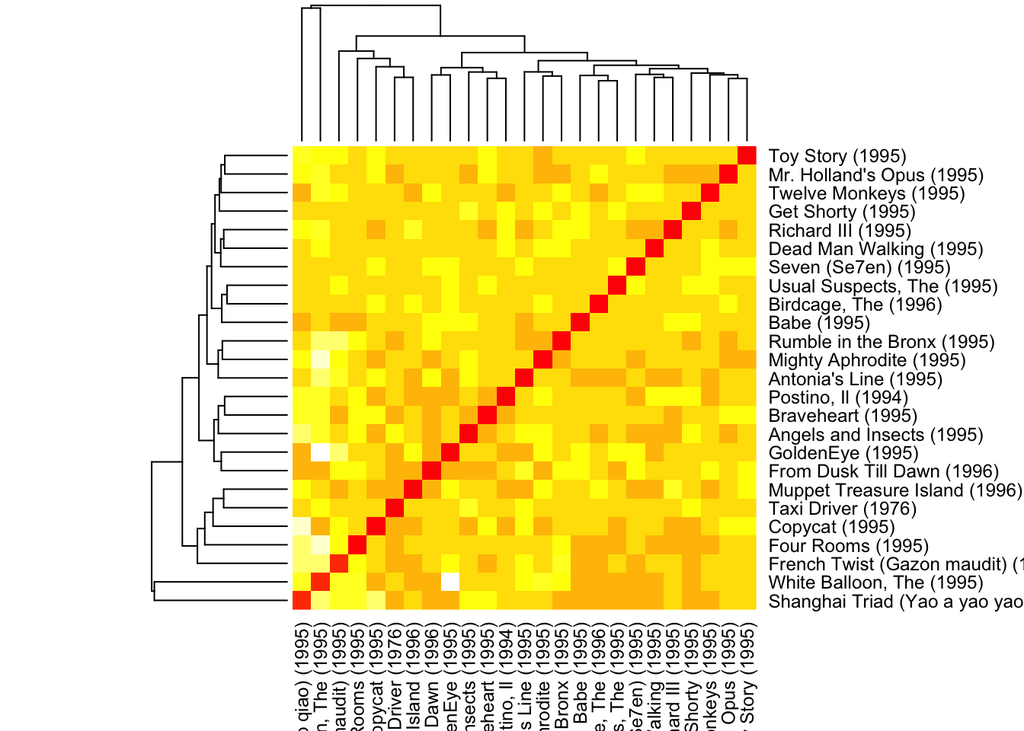

```r
similar_items <- similarity(MovieLense[, 1:25], method = "pearson", which = "items")
heatmap(as.matrix(similar_items))
```

This appears to return more similarity between items, as the yellows are all a lot darker. Next I will use the UBCF method to create a recommender system I will start by creating the training set.

```r
trainI2I2 <- Recommender(movieTrain, method = "UBCF", param=list(normalize = "Z-score", method="Jaccard"))
```

```r
predicted <- predict(object = trainI2I2, newdata = movieTest, n = 10)
rec <- sapply(predicted@items, function(x) {colnames(movies)[x]})
rec %>% kable() %>% kable_styling(full_width = T)
```

| 28 | 38 | 43 | 58 | 70 | 72 | 76 | 85 | 89 | 90 | 91 | 96 | 97 | 106 | 122 | 125 | 135 | 160 | 186 | 198 | 223 | 224 | 250 | 254 | 264 | 288 | 301 | 308 | 314 | 318 | … |
| --- | --- | --- | --- | --- | --- | --- | --- | --- | --- | --- | --- | --- | --- | --- | --- | --- | --- | --- | --- | --- | --- | --- | --- | --- | --- | --- | --- | --- | --- | --- |
| Godfather, The (1972) | Fargo (1996) | Sling Blade (1996) | Secrets & Lies (1996) | Fargo (1996) | Princess Bride, The (1987) | Star Wars (1977) | Close Shave, A (1995) | Raiders of the Lost Ark (1981) | Star Wars (1977) | Fargo (1996) | Dead Man Walking (1995) | Godfather, The (1972) | Star Wars (1977) | Fargo (1996) | Fargo (1996) | Fargo (1996) | Return of the Jedi (1983) | Star Wars (1977) | Dead Man Walking (1995) | Fargo (1996) | Fargo (1996) | Princess Bride, The (1987) | Fargo (1996) | Star Wars (1977) | Dead Man Walking (1995) | Raising Arizona (1987) | Princess Bride, The (1987) | Fargo (1996) | Dead Man Walking (1995) | … |
| Dead Man Walking (1995) | Star Wars (1977) | To Kill a Mockingbird (1962) | To Kill a Mockingbird (1962) | Godfather, The (1972) | Raising Arizona (1987) | Raiders of the Lost Ark (1981) | Toy Story (1995) | Dead Man Walking (1995) | Return of the Jedi (1983) | Dead Man Walking (1995) | Close Shave, A (1995) | Return of the Jedi (1983) | Raiders of the Lost Ark (1981) | Star Wars (1977) | Godfather, The (1972) | Star Wars (1977) | Princess Bride, The (1987) | Raiders of the Lost Ark (1981) | Close Shave, A (1995) | Star Wars (1977) | Star Wars (1977) | Schindler’s List (1993) | Godfather, The (1972) | Raiders of the Lost Ark (1981) | Return of the Jedi (1983) | Close Shave, A (1995) | L.A. Confidential (1997) | Star Wars (1977) | Return of the Jedi (1983) | … |
| Return of the Jedi (1983) | Raiders of the Lost Ark (1981) | Terminator, The (1984) | L.A. Confidential (1997) | Dead Man Walking (1995) | Close Shave, A (1995) | Godfather, The (1972) | Secrets & Lies (1996) | Schindler’s List (1993) | Princess Bride, The (1987) | Princess Bride, The (1987) | Lone Star (1996) | Dead Man Walking (1995) | Godfather, The (1972) | Raiders of the Lost Ark (1981) | Dead Man Walking (1995) | Raiders of the Lost Ark (1981) | Schindler’s List (1993) | Godfather, The (1972) | Lone Star (1996) | Raiders of the Lost Ark (1981) | Raiders of the Lost Ark (1981) | Close Shave, A (1995) | Dead Man Walking (1995) | Godfather, The (1972) | Pulp Fiction (1994) | Lone Star (1996) | Big Night (1996) | Raiders of the Lost Ark (1981) | Princess Bride, The (1987) | … |
| Schindler’s List (1993) | Dead Man Walking (1995) | Wizard of Oz, The (1939) | Mr. Holland’s Opus (1995) | Schindler’s List (1993) | Secrets & Lies (1996) | Dead Man Walking (1995) | Sling Blade (1996) | Pulp Fiction (1994) | Raising Arizona (1987) | Raising Arizona (1987) | Secrets & Lies (1996) | Raising Arizona (1987) | Return of the Jedi (1983) | Return of the Jedi (1983) | Close Shave, A (1995) | Godfather, The (1972) | Raising Arizona (1987) | Dead Man Walking (1995) | Secrets & Lies (1996) | Godfather, The (1972) | Godfather, The (1972) | Lone Star (1996) | Princess Bride, The (1987) | Dead Man Walking (1995) | Raising Arizona (1987) | Secrets & Lies (1996) | Philadelphia Story, The (1940) | Godfather, The (1972) | Close Shave, A (1995) | … |
| Raising Arizona (1987) | Return of the Jedi (1983) | Butch Cassidy and the Sundance Kid (1969) | Young Frankenstein (1974) | Pulp Fiction (1994) | Sling Blade (1996) | Return of the Jedi (1983) | Usual Suspects, The (1995) | Raising Arizona (1987) | Close Shave, A (1995) | Close Shave, A (1995) | Sling Blade (1996) | Schindler’s List (1993) | Princess Bride, The (1987) | Dead Man Walking (1995) | Lone Star (1996) | Dead Man Walking (1995) | Shawshank Redemption, The (1994) | Return of the Jedi (1983) | Sling Blade (1996) | Dead Man Walking (1995) | Dead Man Walking (1995) | Secrets & Lies (1996) | Schindler’s List (1993) | Return of the Jedi (1983) | Close Shave, A (1995) | Sling Blade (1996) | Star Trek: The Wrath of Khan (1982) | Return of the Jedi (1983) | Toy Story (1995) | … |
| Close Shave, A (1995) | Princess Bride, The (1987) | Braveheart (1995) | Vertigo (1958) | Raising Arizona (1987) | L.A. Confidential (1997) | Princess Bride, The (1987) | L.A. Confidential (1997) | Close Shave, A (1995) | Toy Story (1995) | Toy Story (1995) | To Kill a Mockingbird (1962) | Shawshank Redemption, The (1994) | Pulp Fiction (1994) | Princess Bride, The (1987) | Secrets & Lies (1996) | Return of the Jedi (1983) | Sling Blade (1996) | Princess Bride, The (1987) | Usual Suspects, The (1995) | Return of the Jedi (1983) | Return of the Jedi (1983) | To Kill a Mockingbird (1962) | Pulp Fiction (1994) | Schindler’s List (1993) | Toy Story (1995) | L.A. Confidential (1997) | Contact (1997) | Raising Arizona (1987) | Lone Star (1996) | … |
| Shawshank Redemption, The (1994) | Pulp Fiction (1994) | Lawrence of Arabia (1962) | Wizard of Oz, The (1939) | Shawshank Redemption, The (1994) | Young Frankenstein (1974) | Raising Arizona (1987) | Mr. Holland’s Opus (1995) | Shawshank Redemption, The (1994) | Lone Star (1996) | Lone Star (1996) | Usual Suspects, The (1995) | Pulp Fiction (1994) | Raising Arizona (1987) | Raising Arizona (1987) | Sling Blade (1996) | Schindler’s List (1993) | To Kill a Mockingbird (1962) | Schindler’s List (1993) | L.A. Confidential (1997) | Pulp Fiction (1994) | Princess Bride, The (1987) | L.A. Confidential (1997) | Close Shave, A (1995) | Close Shave, A (1995) | Lone Star (1996) | Young Frankenstein (1974) | Postino, Il (1994) | Close Shave, A (1995) | Sling Blade (1996) | … |
| Toy Story (1995) | Raising Arizona (1987) | This Is Spinal Tap (1984) | Butch Cassidy and the Sundance Kid (1969) | Lone Star (1996) | Wizard of Oz, The (1939) | Close Shave, A (1995) | Braveheart (1995) | Lone Star (1996) | Back to the Future (1985) | Secrets & Lies (1996) | Back to the Future (1985) | Lone Star (1996) | Close Shave, A (1995) | Schindler’s List (1993) | Usual Suspects, The (1995) | Raising Arizona (1987) | Usual Suspects, The (1995) | Raising Arizona (1987) | Vertigo (1958) | Raising Arizona (1987) | Pulp Fiction (1994) | Mr. Holland’s Opus (1995) | Lone Star (1996) | Shawshank Redemption, The (1994) | Secrets & Lies (1996) | Vertigo (1958) | Full Monty, The (1997) | Lone Star (1996) | To Kill a Mockingbird (1962) | … |
| Lone Star (1996) | Close Shave, A (1995) | Sting, The (1973) | Braveheart (1995) | Secrets & Lies (1996) | Braveheart (1995) | Toy Story (1995) | Wrong Trousers, The (1993) | Secrets & Lies (1996) | Terminator, The (1984) | Sling Blade (1996) | L.A. Confidential (1997) | L.A. Confidential (1997) | Lone Star (1996) | Close Shave, A (1995) | L.A. Confidential (1997) | Close Shave, A (1995) | Back to the Future (1985) | Close Shave, A (1995) | Butch Cassidy and the Sundance Kid (1969) | Close Shave, A (1995) | Raising Arizona (1987) | Young Frankenstein (1974) | Secrets & Lies (1996) | Toy Story (1995) | Back to the Future (1985) | Butch Cassidy and the Sundance Kid (1969) | Dr. Strangelove or: How I Learned to Stop Worrying and Love the Bomb (1963) | Secrets & Lies (1996) | L.A. Confidential (1997) | … |
| Secrets & Lies (1996) | Shawshank Redemption, The (1994) | Snow White and the Seven Dwarfs (1937) | Snow White and the Seven Dwarfs (1937) | Sling Blade (1996) | Wrong Trousers, The (1993) | Lone Star (1996) | Big Night (1996) | Sling Blade (1996) | Mr. Holland’s Opus (1995) | Usual Suspects, The (1995) | Mr. Holland’s Opus (1995) | Secrets & Lies (1996) | To Kill a Mockingbird (1962) | Shawshank Redemption, The (1994) | Mr. Holland’s Opus (1995) | Shawshank Redemption, The (1994) | Young Frankenstein (1974) | Shawshank Redemption, The (1994) | Braveheart (1995) | Shawshank Redemption, The (1994) | Close Shave, A (1995) | Vertigo (1958) | Sling Blade (1996) | Lone Star (1996) | L.A. Confidential (1997) | Wrong Trousers, The (1993) | Kolya (1996) | Sling Blade (1996) | Terminator, The (1984) | … |

From a quick glance, the second method appears to be much more efficient for this data.